# Abschlußprojekt für Data Analyst: Entwicklung eines Autopreisvorhersagemodells und Integration in ein Dashboard zur Anwendung.

### 4.4.2 Kategorische Spalten mit Ordinal-Encoding + numerische Spalten (standardisiert) → lineares Modell

#### Achtung: hier ist das nur für Testzweck, nicht wirklich geeignet für das Projekt

```
X_train:cat, num, X_Test:cat, num (164, 8) (164, 17) (41, 8) (41, 17)
count of the trainig:  2
r2_score: 0.8494, MSE: 8056836.64
rel. min.: 1.0649612934439567 rel. max.: 56.08712930936035 rel. mean.: 21.026427361409812

Histogram: Relativer Prozentsatz der Preisdifferenz bei der Voraussage
```

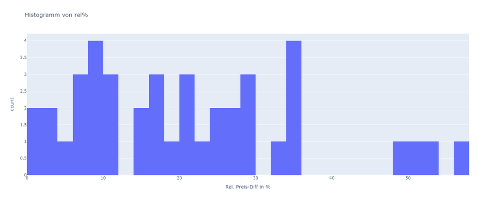

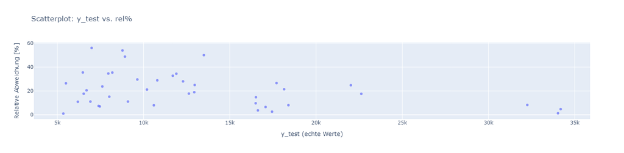

```
     Actual Value  Predicted Value  Difference   rel%
85         6989.0         10908.93    -3919.93  56.09
155        8778.0          4044.79     4733.21  53.92
0         13495.0         20243.09    -6748.09  50.00
28         8921.0         13275.43    -4354.43  48.81
30         6479.0          4179.64     2299.36  35.49
86         8189.0         11091.12    -2902.12  35.44
119        7957.0          5203.61     2753.39  34.60
107       11900.0         16001.36    -4101.36  34.47
149       11694.0          7866.57     3827.43  32.73
168        9639.0         12495.16    -2856.16  29.63
63        10795.0         13917.85    -3122.85  28.93
193       12290.0          8845.39     3444.61  28.03
6         17710.0         22420.98    -4710.98  26.60
89         5499.0          6953.16    -1454.16  26.44
29        12964.0         16206.84    -3242.84  25.01
```

```python
#Ordinal Encoder
#categorical colums as ordinal value + numerical columns (standardisiert) -> Linear model

df_cp= df.copy(deep= True)
"""
def training_carmodel(
    df_cp,
    categorical_columns,
    numerical_columns,
    encoding_mode="onehot",   # "onehot" | "ordinal"
    test_daten_size=0.2,
    squared_cols=0
):
"""

model, ordinal_encoders, onehot_encoder, scaler, feature_names, mse, r2_square, pred_df = (
    training_carmodel(
        df_cp,
        categorical_columns,
        numerical_columns,
        encoding_mode="ordinal",
        test_daten_size=0.2,
        squared_cols=0
    )
)


print(f"r2_score: {r2_square:.4f}, MSE: {mse:.2f}")
print("rel. min.:",pred_df['rel%'].min(), "rel. max.:",pred_df['rel%'].max(), "rel. mean.:",pred_df['rel%'].mean())

print('\nHistogram: Relativer Prozentsatz der Preisdifferenz bei der Voraussage')
fig = px.histogram(pred_df, x='rel%', nbins=30, height=600,
                   title='Histogramm von rel%',
                   labels={'rel%': 'Rel. Preis-Diff in %'})

fig.show()
fig1 = px.scatter(
    pred_df,
    x='Actual Value',   # oder 'y_test', je nachdem wie deine Spalte heißt
    y='rel%',
    title='Scatterplot: y_test vs. rel%',
    labels={'Actual Value': 'y_test (echte Werte)', 'rel%': 'Relative Abweichung [%]'},
    opacity=0.7
)
fig1.show()

top10_rel = pred_df.sort_values("rel%", ascending=False).head(15)
print(top10_rel.round(2))
```

### Das Ergebnis:

- One-Hot Encoding ist besser als bei Ordinal-Encoding.
- OrdinalEncoder hat negativen Wert für den Datensatz 18, völlig falschen Wetrt.!!!

### 4.4.3. Kategorische Spalten mit Onehot-Encoding + numerische Spalten (standardisiert) + Ausreißer behandeln → lineares Modell

### Aufbereitung von highwaympg: limit_highwaympg_r=52

### Wenn highwaympg > 52, die Zeile wird als Ausreißer gelöscht. Es gibt zwei Ausreißer

zu testen ob das Ergebnis besser wird. Ergebnis: es wird nicht besser.

```
X_train:cat, num, X_Test:cat, num (162, 33) (162, 17) (41, 33) (41, 17)
count of the trainig:  3
r2_score: 0.9388, MSE: 3456808.78
rel %. min.: 0.28555203001272933 rel. max.: 50.82429914599248 rel. mean.: 13.160013157323311

Histogram: Relativer Prozentsatz der Preisdifferenz bei der Voraussage
```

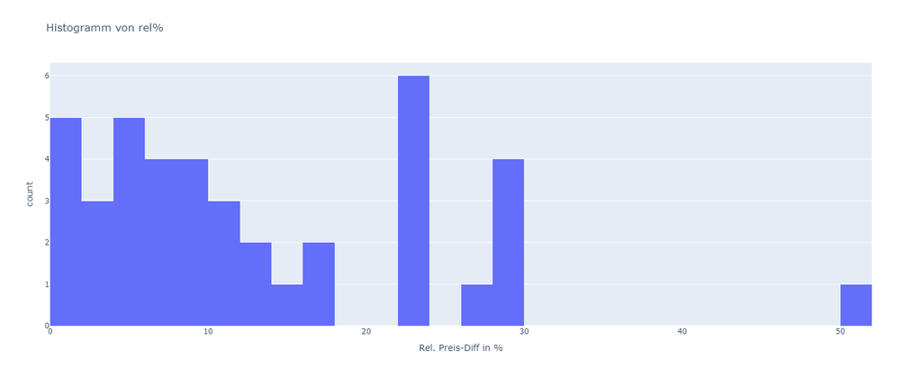

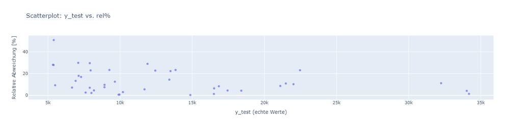

```
     Actual Value  Predicted Value  Difference   rel%
32         5399.0          8143.00    -2744.00  50.82
90         7099.0          9219.26    -2120.26  29.87
154        7898.0          5554.28     2343.72  29.67
107       11900.0         15354.07    -3454.07  29.03
150        5348.0          6848.66    -1500.66  28.06
76         5389.0          6895.85    -1506.85  27.96
162        9258.0          7093.61     2164.39  23.38
192       13845.0         10615.04     3229.96  23.33
203       22470.0         17271.61     5198.39  23.13
119        7957.0          6133.65     1823.35  22.92
109       12440.0         15269.50    -2829.50  22.75
0         13495.0         16500.00    -3005.00  22.27
141        7126.0          8404.56    -1278.56  17.94
35         7295.0          8529.16    -1234.16  16.92
195       13415.0         15355.05    -1940.05  14.46
```

```python
df_cp= df.copy(deep= True)

# entfernen die Zeilen wo  df['highwaympg'] >= limit_highwaympg_r]
df_cp= df_cp.loc[df_cp['highwaympg'] < limit_highwaympg_r]

model, ordinal_encoders, onehot_encoder, scaler, feature_names, mse, r2_square, pred_df = (
    training_carmodel(
        df_cp,
        categorical_columns,
        numerical_columns,
        encoding_mode="onehot",
        test_daten_size=0.2,
        squared_cols=0
    )
)
print(f"r2_score: {r2_square:.4f}, MSE: {mse:.2f}")
print("rel %. min.:",pred_df['rel%'].min(), "rel. max.:",pred_df['rel%'].max(), "rel. mean.:",pred_df['rel%'].mean())

print('\nHistogram: Relativer Prozentsatz der Preisdifferenz bei der Voraussage')
fig = px.histogram(pred_df, x='rel%', nbins=30, height=600,
                   title='Histogramm von rel%',
                   labels={'rel%': 'Rel. Preis-Diff in %'})

fig.show()
fig1 = px.scatter(
    pred_df,
    x='Actual Value',   # oder 'y_test', je nachdem wie deine Spalte heißt
    y='rel%',
    title='Scatterplot: y_test vs. rel%',
    labels={'Actual Value': 'y_test (echte Werte)', 'rel%': 'Relative Abweichung [%]'},
    opacity=0.7
)

fig1.show()
top10_rel = pred_df.sort_values("rel%", ascending=False).head(15)
#print(top10_rel)
print(top10_rel.round(2))
```

```python
import joblib

# Speichern
joblib.dump(model, "linear_model_CarPricePred.pkl")
```

```
['linear_model_CarPricePred.pkl']
```

### 4.4.4 Kategorische Spalten mit OneHot-Encoding + numerische Spalten (standardisiert) + Transformation durch sqrt() oder x^2

```
modellieren nicht linearen Anteil von  numerische Spalten durch zusätzliche Spalten
- squared_cols=1: sqrt(x) ; wenn x< 0 , -sqrt(abs(x)
- squared_cols=2: x^2
```

#### Ergebnis: es wird nicht besser.

```
X_train:cat, num, X_Test:cat, num (164, 33) (164, 33) (41, 33) (41, 33)
count of the trainig:  4
r2_score: 0.9033, MSE: 5172127.80
rel %. min.: 0.536906498209128 rel. max.: 92.52956188846294 rel. mean.: 14.458026529733937

Histogram: Relativer Prozentsatz der Preisdifferenz bei der Voraussage
```

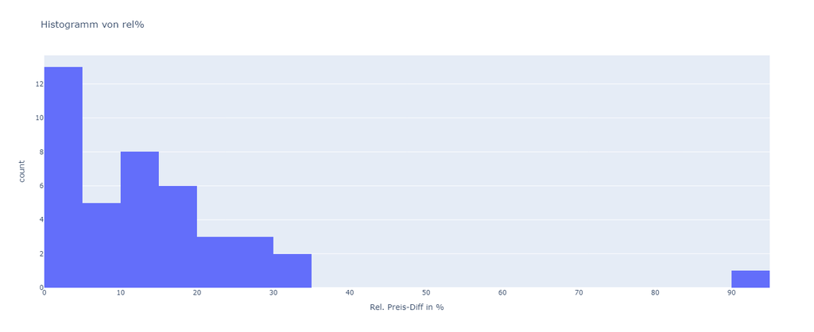

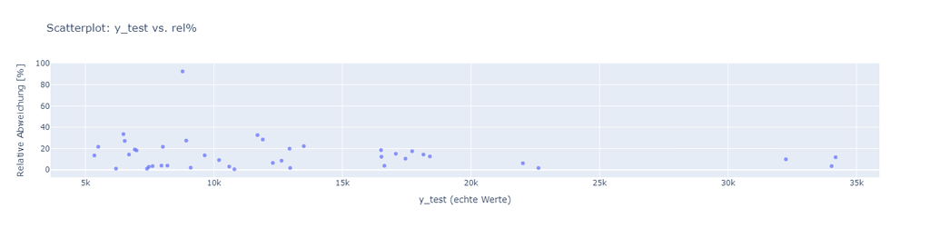

```
     Actual Value  Predicted Value  Difference   rel%
155        8778.0         16900.24    -8122.24  92.53
30         6479.0          4306.56     2172.44  33.53
149       11694.0          7871.52     3822.48  32.69
107       11900.0         15302.28    -3402.28  28.59
28         8921.0          6464.15     2456.85  27.54
33         6529.0          8304.52    -1775.52  27.19
0         13495.0         16500.00    -3005.00  22.27
148        8013.0          9750.83    -1737.83  21.69
89         5499.0          6687.27    -1188.27  21.61
194       12940.0         15517.61    -2577.61  19.92
153        6918.0          5595.69     1322.31  19.11
2         16500.0         13447.36     3052.64  18.50
85         6989.0          8265.63    -1276.63  18.27
6         17710.0         20815.93    -3105.93  17.54
114       17075.0         14486.49     2588.51  15.16
```

```python
df_cp= df.copy(deep= True)

# entfernen die Zeilen wo  df['highwaympg'] >= limit_highwaympg_r]
#df_cp= df_cp.loc[df_cp['highwaympg'] < limit_highwaympg_r]

model, ordinal_encoders, onehot_encoder, scaler, feature_names, mse, r2_square, pred_df = (
    training_carmodel(
        df_cp,
        categorical_columns,
        numerical_columns,
        encoding_mode="onehot",
        test_daten_size=0.2,
        squared_cols=1
    )
)
print(f"r2_score: {r2_square:.4f}, MSE: {mse:.2f}")
print("rel %. min.:",pred_df['rel%'].min(), "rel. max.:",pred_df['rel%'].max(), "rel. mean.:",pred_df['rel%'].mean())

print('\nHistogram: Relativer Prozentsatz der Preisdifferenz bei der Voraussage')
fig = px.histogram(pred_df, x='rel%', nbins=30, height=600,
                   title='Histogramm von rel%',
                   labels={'rel%': 'Rel. Preis-Diff in %'})

fig.show()
fig1 = px.scatter(
    pred_df,
    x='Actual Value',   # oder 'y_test', je nachdem wie deine Spalte heißt
    y='rel%',
    title='Scatterplot: y_test vs. rel%',
    labels={'Actual Value': 'y_test (echte Werte)', 'rel%': 'Relative Abweichung [%]'},
    opacity=0.7
)

fig1.show()
top10_rel = pred_df.sort_values("rel%", ascending=False).head(15)
print(top10_rel.round(2))
```

```python
df_cp= df.copy(deep= True)
#df_cp.info()
#df= df.loc[df['highwaympg'] < 52 ]
#df= df.loc[df['highwaympg'] < limit_highwaympg_r] # df is cleaned for 'highwaympg'] < limit_highwaympg_r
#df.info()
#df.cylindernumber.unique()
```

```python
print("fueltype:",df_cp['fueltype'].unique())
print("fuelsystem:",df_cp['fuelsystem'].unique())
print("carbody:",df_cp['carbody'].unique())
print("drivewheel:",df_cp['drivewheel'].unique())
print("enginelocation:", df_cp['enginelocation'].unique())
print("enginetype:",df_cp['enginetype'].unique())
print("brand:",df_cp['brand'].unique())
#print("model:",df_cp['model'].unique())
#categorical_columns = ['fueltype', 'aspiration',  'carbody', 'drivewheel','enginelocation', 'enginetype', 'fuelsystem', 'brand', 'model']
```

```
fueltype: ['gas' 'diesel']
fuelsystem: ['fuel_injection' 'carburetor' 'diesel_injection']
carbody: ['open' 'utility' 'passenger']
drivewheel: ['rwd' 'fwd' '4wd']
enginelocation: ['front' 'rear']
enginetype: ['dohc' 'ohc_family' 'simple' 'rotor']
brand: ['alfa-romero' 'audi' 'bmw' 'chevrolet' 'dodge' 'honda' 'isuzu' 'jaguar'
 'mazda' 'buick' 'mercury' 'mitsubishi' 'nissan' 'peugeot' 'plymouth'
 'porsche' 'renault' 'saab' 'subaru' 'toyota' 'volkswagen' 'volvo']
```

# 5. Evaluation (Bewertung und Interpretation der Ereignisse)

## 5.1 Modellbewertung

Es gibt kategorische und numerische Daten. Für Machine-Learning müssen die Kategorie in Zahl umgewandelt werden.

Es sind hier zwei Methoden OneHot Encoding und Ordinal Encoding getest. Ordinal-Encoding darf hier nicht benutzt werden weil OrdinalEncoder nicht die Realität der Kategorien darstellt.

### Mit Stratified bins für Regression:

y_bins = pd.qcut(y, q=5, duplicates='drop')

| Methode | R² Score | rel. min. | rel. max. | rel. mean. |
| --- | --- | --- | --- | --- |
| OneHot-Encoding | 0.95 | 0.20 | 34.42 | 11.42 |
| Ordinal-Encoding | 0.85 | 1.06 | 56.08 | 21.02 |
| OneHot-Encoding - Ausreißer | 0.93 | 0.28 | 50.82 | 13.16 |
| OneHot-Encoding + Sqrt() | 0.90 | 0.53 | 92.52 | 14.45 |

### Ohne Stratified bins für Regression(not calculated here)

| Methode | R² Score | rel. min. | rel. max. | rel. mean. |
| --- | --- | --- | --- | --- |
| OneHot-Encoding | 0.91 | 1.09 | 58.97 | 13.68 |
| Ordinal-Encoding | 0.85 | 0.06 | 165.1 | 20.40 |
| OneHot-Encoding - Ausreißer | 0.88 | 0.30 | 45.58 | 13.70 |
| OneHot-Encoding + Sqrt() | 0.90 | 1.34 | 47.91 | 13.33 |

### 5.2. Schlussfolgerung:

1. Das OneHot-Encoding erzielt die beste Modellperformance und stellt aus maschineller-lernmethodischer Sicht die korrekte Kodierung für die vorliegenden kategorialen Merkmale dar.
2. Das Ordinal-Encoding wurde ausschließlich zu experimentellen Vergleichszwecken eingesetzt, um dessen Einfluss auf die Modellgüte zu analysieren. Aufgrund der impliziten Ordnungsannahme ist Ordinal-Encoding für das Zielmodell fachlich nicht geeignet und wird im finalen Projekt nicht verwendet.

# 6. Deployment (Anwendung der Ergebnisse)

## 6.1 Rahmenbedingungen für das Modelltraining und die Preisvorhersage

Das Onehot_Encoding liefert die besten Ergebnisse und wird daher für das Modelltraining eingesetzt:

**Kategorische Spalten als Onehot-Spalten + numerische Spalten (standardisiert) → Lineares Modell**

Die folgenden Überlegungen bilden die Grundlage des Modelltrainings:

1. Die Daten umfassen verschiedene Autohersteller und -modelle. Die Preise liegen im Bereich von **min. 5.118 €** bis **max. 45.400 €**.
2. Das Unternehmen (Auftraggeber) soll die Möglichkeit haben, ein Modell gezielt für ein bestimmtes Preissegment zu trainieren.
3. Das Dashboard bietet die Option, ein gewünschtes Preissegment auszuwählen.
4. Das Modell wird anschließend auf die Daten des ausgewählten Preisbereichs trainiert.
5. Auf Basis des trainierten Modells kann das Unternehmen durch Eingabe bestimmter Parameter **Preisvoraussagen** durchführen.

**Parameter für das Modelltraining:**

encoding_mode: "onehot" fest

test_daten_size: 0.2 wählbar

squared_cols: 0 fest

Preisbereich: Auswahl durch Anwender wählbar

## 6.2 Dashborad für Modelltraining

### Bedingungsanweisung für das Dashboard

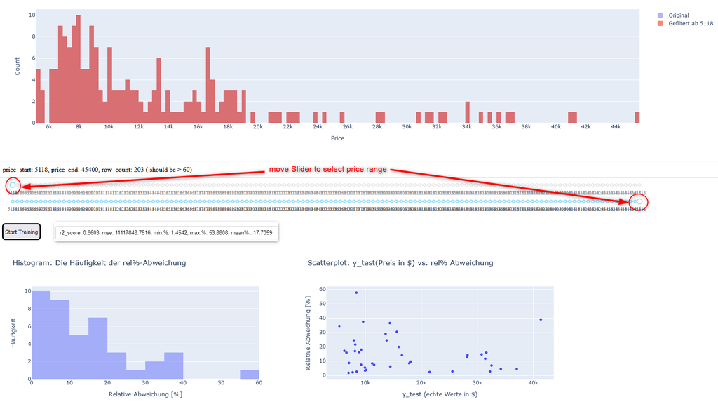

### Bedingungsanweisung für das Dashboard

1. **Initialisierung beim Start**
   - Beim Starten des Dashboards wird das Modell mit den **gesamten Daten** trainiert.
   - Folgende Darstellungen sind sichtbar:
     - **Histogramm der Preise**
     - **Textfeld** zur Anzeige der Modellergebnisse
     - **Histogramm der relativen Abweichungen (%)** für die Testdaten
     - **Scatterplot** der Preisdifferenzen für einzelne Werte
2. **Auswahl des Preissegments**
   - Zwei Slider ermöglichen die Auswahl eines **Preisbereichs**.
   - Beim Verschieben der Slider wird das **Histogramm der ausgewählten Datensätze** angezeigt.
   - Das neue Histogramm wird **über dem Original-Histogramm** dargestellt, sodass der ausgewählte Bereich klar erkennbar ist.
3. **Training mit ausgewählten Datensätzen**
   - Durch Drücken des Buttons **„Start Training“** wird das Modell mit den **ausgewählten Daten** (Teil der Gesamtdaten) trainiert.
   - Die Darstellungen (Histogramme, Scatterplot, Textfeld) werden nach dem Training **aktualisiert**.
4. **Bewertung der Ergebnisse**
   - Die Qualität des Modells kann anhand der **angezeigten Werte** in den Diagrammen und Textfeldern bewertet werden.

```python
#df= df.loc[df['highwaympg'] < limit_highwaympg_r] # df is cleaned for 'highwaympg'] < limit_highwaympg_r
# def training_carmodel(df_cp, categorical_columns, numerical_columns,encoding_mode=2, test_daten_size=0.2, squared_cols=0):
df_cp= df.copy(deep= True)
df_cp= df_cp.loc[df['highwaympg'] < 52]
#df.info()
start_price = float(df_cp['price'].min())
end_price = float(df_cp['price'].max())
print(type(start_price))
start_price, end_price
```

```
<class 'float'>
```

```
(5118.0, 45400.0)
```

```python
count_train=0
```

```python
import dash
from dash import Dash, dcc, html, Input, Output, callback
import plotly.express as px
import plotly.graph_objects as go
import json
import pandas as pd


global model_train, label_encoders_train, onehot_encoder_train, feature_names_train,scaler_train, mse_train, r2_square_train, df_pred_train
global df_train    # copy of orig. df
global df_filtered # filtered df for ineractive modelltraining

row_count=203
df_train= df.copy(deep= True) # df_train is changed after Training

external_stylesheets = ['https://codepen.io/chriddyp/pen/bWLwgP.css']

app = Dash(__name__, external_stylesheets=external_stylesheets)
styles = {
    'pre': {
        'border': 'thin lightgrey solid',
        'overflowX': 'scroll'
    }
}
slider_value_l=0
slider_value_r=50000
slider_trained_l=0
slider_trained_r=50000

# inital Modelltraining
# entfernen die Zeilen wo  df['highwaympg'] >= limit_highwaympg_r] limit_highwaympg_r=52

"""
model_train, label_encoders_train,scaler_train, mse_train, r2_square_train, df_pred_train =  training_carmodel(df_train,
                                              categorical_columns, numerical_columns, 2, test_daten_size=0.2, squared_cols=0)

model, ordinal_encoders, onehot_encoder, feature_names, scaler, mse, r2_square, pred_df = (
    training_carmodel(
        df_train,
        categorical_columns,
        numerical_columns,
        encoding_mode="onehot",
        test_daten_size=0.2,
        squared_cols=0
    )
)

"""

model_train, label_encoders_train, onehot_encoder_train, scaler_train,feature_names_train, mse_train, r2_square_train, df_pred_train = (
    training_carmodel(
        df_train,
        categorical_columns,
        numerical_columns,
        encoding_mode="onehot",
        test_daten_size=0.2,
        squared_cols=0
    )
)

#print("0: feature_names_train:", len(feature_names_train), feature_names_train)

#show the relative deviation of the price : abs(price_diff) / price_orig *100: -> 'rel%': abs((y_test - y_pred)) / y_test * 100
# print("min.:",df_pred_train['rel%'].min(), "max.:",df_pred_train['rel%'].max(), "mean.:",df_pred_train['rel%'].mean())

my_outstr = (
    f"r2_score: {r2_square_train:.4f},  "
    f"mse: {mse:.4f},  "
    f"min.%: {df_pred_train['rel%'].min():.4f},  "
    f"max.%: {df_pred_train['rel%'].max():.4f},  "
    f"mean%.: {df_pred_train['rel%'].mean():.4f}"
    )
# show original price histogram: go.Histogram() create histogram
# size=300 ist the balkensize, 300 means 300$ for the Bin-width
# height=400 height in pixel, ähnlic wie 'height': '400px' in CSS. aber als string '400px' angegeben.
# for plotly: besser height=400
orig_hist = go.Histogram(
        x=df['price'],
        xbins=dict(
        size=300      # Balkenabstand bzw. Bin-Größe
        ),
        nbinsx=40,
        opacity=0.5,
        name='Original'
    )
fig = go.Figure(orig_hist)

'''
fig.update_layout(
    height=400,   # Höhe in Pixel
    width=800     # optional auch Breite
)
'''
app.layout = html.Div([
    # Erst das Histogramm
    html.Div(
        dcc.Graph(id='compare_histogram', style={ 'width': '100%'}), # 'height':'500px',
        style={'width': '100%', 'padding': '10px'}
    ),

  html.Div(id='result_text', style={'whiteSpace': 'pre-line', 'padding': '10px', 'border': '1px solid #ccc'}),
    # Dann das Slider-DIV darunter
    html.Div([
        #html.Label('Slider Links'),
        dcc.Slider(
            id='price_slider_l',
            min=float(start_price),
            max=float(end_price),
            value=float(start_price),
            step=300.0,
            marks={i: str(i) for i in range(int(start_price), int(end_price)+1, 300)}
        ),

        #html.Label('Slider Rechts'),
        dcc.Slider(
            id='price_slider_r',
            min=float(start_price),
            max=float(end_price),
            value=float(end_price),
            step=300.0,             #300$ a step
            marks={i: str(i) for i in range(int(start_price), int(end_price)+1, 300)}
        )
    ], style={'width': '90%', 'padding': '10px'}),


    # 2 elements in a DIV: button + histogram
    html.Div([
        html.Div([
             html.Button('Start Training',
                id='refresh_button',
                n_clicks=0,
                style={
                        'margin': '10px',
                        'height': '40px',
                        'border': '3px solid black',   # <--- hier wird der Rahmen dicker
                        'borderRadius': '8px'          # optional: abgerundete Ecken
                         }
                       ),

                    dcc.Input(
                        id='output_trained',
                        type='text',
                        #placeholder='10000',
                        value=my_outstr,
                        style={'width': '100%'}
                    ),


              html.Div(id='alert_message',
              style={
                 'color': 'red',
                 'margin': '10px',
                 'fontWeight': 'bold'

             })
            ], style={'display': 'flex', 'alignItems': 'center'}),

         html.Div([
               dcc.Graph( id='rel_histogram',
                   figure=go.Figure( data=[go.Histogram(x= df_pred_train['rel%'])],
                   layout=go.Layout(height=400,
                                    width=700,
                                    title='Histogram: Die Häufigkeit der rel%-Abweichung',
                                    xaxis_title='Relative Abweichung [%]',
                                    yaxis_title='Häufigkeit'
                                   )
                                 )
                     ),

              dcc.Graph(id='scatter_plot',
                  figure=go.Figure(
                         data=[go.Scatter(
                         x=df_pred_train['Actual Value'],
                         y=df_pred_train['rel%'],
                         mode='markers',
                         opacity=0.7,
                          marker=dict(color='blue')
                         )],
                  layout=go.Layout(
                       height=400,
                       width=400,
                       title='Scatterplot: y_test(Preis in $) vs. rel% Abweichung',
                       xaxis_title='y_test (echte Werte in $)',
                       yaxis_title='Relative Abweichung [%]'
                         )
                        )
                        )
```

```python
                ], style={'display': 'flex', 'alignItems': 'center'} )


            ], style={'width': '100%'})


      ] , style={'width': '90%', 'margin': 'auto'})


# check if enough rows exist
@app.callback(
    Output('alert_message', 'children'),
    Input('price_slider_l', 'value'),
    Input('price_slider_r', 'value')
)

def validate_inputs(slider_value_l, slider_value_r):
    df_train = df.copy(deep=True)

    if slider_value_l > slider_value_r:
       sl_val=slider_value_r
       slider_value_r= slider_value_l
       slider_value_l=  sl_val


    df_filtered = df_train[(df_train['price'] >= slider_value_l) & (df_train['price'] <= slider_value_r)]
    row_count = len(df_filtered)

    if row_count < 60:
        return f"⚠️ Achtung: Gefilterte Datenmenge ist zu klein (nur {row_count} Zeilen, benötigt > 60)."

    return ""



@app.callback(
    Output('compare_histogram', 'figure'),
    Output('result_text', 'children'),
    Input('price_slider_l', 'value'),
    Input('price_slider_r', 'value')
)
def update_compare_histogram(slider_value_l,slider_value_r):
    # Ungefiltertes Histogramm
    # slider_value_l: left value
    # slider_value_r: right value
    import plotly.graph_objects as go
    global df_filtered, row_count

    # why do the copy hier: df_filtered is a part of df_train. they have the same memory area.
    # wenn f_filtered is changed, then memory of df_train is also changed even if df_train seem to be not be changed
    df_train= df.copy(deep= True)
    if slider_value_l > slider_value_r:
       sl_val=slider_value_r
       slider_value_r= slider_value_l
       slider_value_l=  sl_val

    df_filtered = df_train[(df_train['price'] >= slider_value_l) & (df_train['price'] <= slider_value_r)]
    # a0, a1, ...a29: 30 variable to be calculated, row_count should be 60 (48 for training, 12 for testing
    row_count= len( df_filtered )
    #print("row_count=", row_count)

    # Gefiltertes Histogramm
    filtered_hist = go.Histogram(
        x=df_filtered['price'],
        xbins=dict(
        size=300      # Balkenabstand bzw. Bin-Größe
        ),
        opacity=0.7,
        name=f'Gefiltert ab {slider_value_l}'
    )
    # Beide Histogramme in einer Figure
    fig = go.Figure([orig_hist, filtered_hist])
    fig.update_layout(
        barmode='overlay',
        xaxis_title='Price',
        yaxis_title='Count',
        title='Distribution of Price (Vergleich Original & Gefiltert)',
        height=450 #600
    )
    fig.update_xaxes(
        tickmode='linear',
        tick0=0,
        dtick=2000
    )
    mystr = f"price_start: {slider_value_l}, price_end: {slider_value_r}, row_count: {row_count} ( should be > 60)"
    return fig, mystr


@app.callback(
    Output('rel_histogram', 'figure'),
    Output('scatter_plot', 'figure'),
    Output('output_trained', 'value'),
    Input('refresh_button', 'n_clicks')
)

def update_rel_histogram(n_clicks):
    import plotly.graph_objects as go
    global model_train, label_encoders_train, onehot_encoder_train, scaler_train, feature_names_train, mse_train, r2_square_train, df_pred_train
    global df_filtered
    global slider_trained_l, slider_trained_r

    # start the modeltraining
    """
    model_train, label_encoders_train,onehot_encoder_train,feature_names_train, scaler_train, mse_train, r2_square_train, df_pred_train =
    training_carmodel(
    df_filtered, categorical_columns, numerical_columns, 2, test_daten_size=0.2, squared_cols=0
        )

    model_train, label_encoders_train, onehot_encoder_train, feature_names_train, scaler_train, mse_train, r2_square_train, df_pred_train = (
    training_carmodel(
        model_train,
        categorical_columns,
        numerical_columns,
        encoding_mode="onehot",
        test_daten_size=0.2,
        squared_cols=0
    )
    )
    """
    if n_clicks and n_clicks > 0 and row_count >= 60:
        result= training_carmodel(
        df_filtered,
        categorical_columns,
        numerical_columns,
        encoding_mode="onehot",
        test_daten_size=0.2,
        squared_cols=0,
        )

        (
        model_train,
        label_encoders_train,
        onehot_encoder_train,
        scaler_train,
        feature_names_train,
        mse_train,
        r2_square_train,
        df_pred_train,
        ) = result

        #print("1. feature_names_train:",len(feature_names_train),feature_names_train)

    # save the price range for price prediction
        slider_trained_l = slider_value_l
        slider_trained_r = slider_value_r

    # print("r2_score:",  r2_square_train, "mse:", mse, min.:",df_pred_train['rel%'].min(), "max.:",df_pred_train['rel%'].max(), "mean.:",df_pred_train['rel%'].mean())

    my_outstr = (
    f"r2_score: {r2_square_train:.4f}, "
    f"mse: {mse:.4f}, "
    f"min.%: {df_pred_train['rel%'].min():.4f}, "
    f"max.%: {df_pred_train['rel%'].max():.4f}, "
    f"mean%.: {df_pred_train['rel%'].mean():.4f}"
    )

    #print(my_outstr)

    rel_hist = go.Histogram(
            x= df_pred_train['rel%'],
            xbins=dict(size=5),
            nbinsx=100,
            opacity=0.5,
            name='relative in %'
        )
    fig = go.Figure(rel_hist)
    #fig.update_layout(title='relative Abweichung')
    fig.layout=go.Layout(height=400,
                         width=700,
                         title='Histogram: Die Häufigkeit der rel%-Abweichung',
                         xaxis_title='Relative Abweichung [%]',
                         yaxis_title='Häufigkeit'
                                   )


    #--------------------
    scatter_plt = go.Scatter(
                x=df_pred_train['Actual Value'],
                y=df_pred_train['rel%'],
                mode='markers',
                opacity=0.7,
                marker=dict(color='blue')
                )

    fig1 = go.Figure(scatter_plt)
    fig1.update_layout(
                title='Scatterplot: y_test(Preis in $) vs. rel% Abweichung',
                xaxis_title='y_test (echte Werte in $)',
                yaxis_title='Relative Abweichung [%]',
                height=400,
                width=700
                  )
```

```python
  #---------------------------

    return fig, fig1, my_outstr


if __name__ == '__main__':
    app.run(debug=True, port=8050)
```

```
X_train:cat, num, X_Test:cat, num (164, 33) (164, 17) (41, 33) (41, 17)
count of the trainig:  1
```

[interactive chart not shown]

## 6.3 Dashboard für Preisvoraussage(price prediction)

## Bedingungsanweisung für das Dashboard

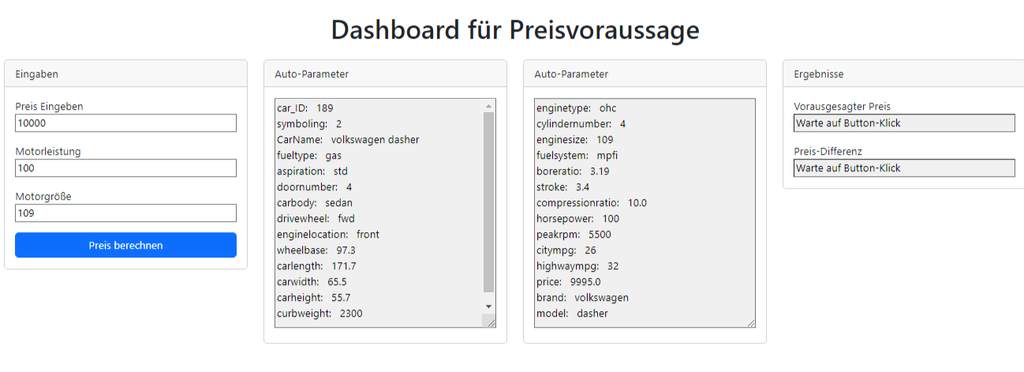

### 1. Textfeld: Preiseingabe

- Der Anwender gibt hier den gewünschten Preis ein.
- Basierend auf diesem Preis sucht das Dashboard den **bestangepassten Datensatz** aus den Trainingsdaten.
- Der gefundene Datensatz wird in den beiden Auto-Parameter-Fenstern angezeigt, sodass der Anwender **alle Parameter** einsehen kann.
- **Parameter-Zuordnung:**
  - `horsepower` → Fenster „Motorleistung“
  - `enginesize` → Fenster „Motorgröße“

### 2. Textfeld: Motorleistung (`horsepower`)

- Motorleistung kann hier angepasst werden.
- Dieser Wert wird für die **Preisvoraussage** als veränderliche Größe verwendet.

### 3. Textfeld: Motorgröße (`enginesize`)

- Motorgröße kann hier angepasst werden.
- Dieser Wert wird für die **Preisvoraussage** als veränderliche Größe verwendet.

### 4. Textarea: Auto-Parameter

- Dient als **Informationsfenster** für den ausgewählten Datensatz.
- Alle Parameter des Datensatzes werden hier in **zwei Bereichen** angezeigt.

### 5. Button: Preis Berechnen

- Berechnet den Preis für die **veränderten Parameter** `horsepower` und `enginesize`.

### 6. Textfeld: Vorausgesagter Preis

- Zeigt den berechneten Preis für die aktuellen Parameter an.

### 7. Textfeld: Preis-Differenz

- Zeigt die **Differenz** zwischen dem vorausgesagten Preis und dem Preis des ausgewählten Datensatzes.

```python
import dash
from dash import dcc, html, Input, Output, State
import dash_bootstrap_components as dbc

# Initialisiere die Dash-App
app = dash.Dash(__name__, external_stylesheets=[dbc.themes.BOOTSTRAP])

# Initialwerte
initial_value_3 = 0
initial_value_4 = 0
app.layout = dbc.Container([
    html.H1("Dashboard für Preisvoraussage", className="my-4 text-center"),

    dbc.Row([
        # Spalte 1: Inputs
        dbc.Col(dbc.Card([
            dbc.CardHeader("Eingaben"),
            dbc.CardBody([
                html.Div([
                    html.Label("Preiseingeben"),
                    dcc.Input(
                        id='price_input',
                        type='text',
                        placeholder='10000',
                        value='10000',
                        style={'width': '100%'}
                    ),
                ], className="mb-3"),

                html.Div([
                    html.Label("Motorleistung"),
                    dcc.Input(
                        id='ps_value',
                        type='number',
                        value=initial_value_3,
                        style={'width': '100%'}
                    ),
                ], className="mb-3"),

                html.Div([
                    html.Label("Motorgröße"),
                    dcc.Input(
                        id='motor_size',
                        type='number',
                        value=initial_value_4,
                        style={'width': '100%'}
                    ),
                ], className="mb-3"),

                dbc.Button("Preis berechnen", id='action-button', n_clicks=0,
                           color="primary", className="w-100"),
            ])
        ]), width=3),

        # Spalte 2: Parameter-Info: part 1
        dbc.Col(dbc.Card([
            dbc.CardHeader("Auto-Parameter"),
            dbc.CardBody([
                dcc.Textarea(
                    id='parameter_info',
                    readOnly=True,
                    value='',
                    style={
                        'width': '100%',
                        'height': '350px',
                        'backgroundColor': '#f0f0f0',
                        'resize': 'vertical'
                    }
                ),
            ])
        ]), width=3),

        # Spalte 3: Parameter-Info: part 2
        dbc.Col(dbc.Card([
            dbc.CardHeader("Auto-Parameter"),
            dbc.CardBody([
                dcc.Textarea(
                    id='parameter_info1',
                    readOnly=True,
                    value='',
                    style={
                        'width': '100%',
                        'height': '350px',
                        'backgroundColor': '#f0f0f0',
                        'resize': 'vertical'
                    }
                ),
            ])
        ]), width=3),


        # Spalte 4: Ergebnisse
        dbc.Col(dbc.Card([
            dbc.CardHeader("Ergebnisse"),
            dbc.CardBody([
                html.Div([
                    html.Label("Vorausgesagter Preis"),
                    dcc.Input(
                        id='price_pred',
                        type='text',
                        readOnly=True,
                        value='Warte auf Button-Klick',
                        style={'width': '100%', 'backgroundColor': '#f0f0f0'}
                    ),
                ], className="mb-3"),

                html.Div([
                    html.Label("Preis-Differenz"),
                    dcc.Input(
                        id='price_diff',
                        type='text',
                        readOnly=True,
                        value='Warte auf Button-Klick',
                        style={'width': '100%', 'backgroundColor': '#f0f0f0'}
                    ),
                ]),
            ])
        ]), width=3),
    ]),
], fluid=True)


# Callback für Nr. 1 und Nr. 2
# Wenn Enter in input-1 gedrückt wird, wird der Wert in output-2 aktualisiert.
# price_input  1
# parameter_info 2
# ps_value 3
# motor_size 4
# action-button
# price_pred  5
# price_diff  6

@app.callback(
    Output('parameter_info', 'value'),
    Output('parameter_info1', 'value'),
    Output('ps_value', 'value'),
    Output('motor_size', 'value'),
    Input('price_input', 'n_submit'),
    State('price_input', 'value'),
    #prevent_initial_call=True
)
def update_para_ps_engine_size(n_submit, price_input_value):
    #slider_trained_l, slider_trained_r
    global item_car_info

    if not price_input_value:
        return "Bitte Preis eingeben"
    # use orig df, df_filtered_pred_new is no allowed to change
    df_filtered_pred_new = df[(df['price'] >= slider_trained_l) & (df['price'] <= slider_trained_r)]
    price_val = float(price_input_value) # string to float
    len_pred_new = len(df_filtered_pred_new)
    # search for item in df_filtered_pred_new
    idx_nearest = None
    price_nearest = None

    # search for the nearst price index
    idx_nearest = (df_filtered_pred_new['price'] - price_val).abs().idxmin()

    price_nearest = df.loc[idx_nearest, 'price']
    #print(idx_nearest, price_nearest)
    ps_val= df.loc[idx_nearest, 'horsepower']
    motor_size_val= df.loc[idx_nearest, 'enginesize']

    item_info_str = []
    parts_str=[]
    run_idx = 0

    if idx_nearest is not None:
        item_car_info = df_filtered_pred_new.loc[idx_nearest]
        #print("item_car_info: type", type(item_car_info))
        for col, val in item_car_info.items():
          item_info_str = '\n'.join(f"{col}:   {val}" for col, val in item_car_info.items())
        parts_str = item_info_str.split("enginetype", 1)
        parts_str[1]='enginetype'+ parts_str[1]

    #item_info_str = '\n'.join(f"{col}: {val}" for col, val in item_info.items())


    return parts_str[0], parts_str[1], str(ps_val), str(motor_size_val)

# Callback für den Button und Felder 5 & 6
# Der Button löst eine Aktion aus, die die Werte in Feld 5 und 6 aktualisiert.
@app.callback(
    Output('price_pred', 'value'),
    Output('price_diff', 'value'),
    Input('action-button', 'n_clicks'),
    State('ps_value', 'value'), # Werte von input-3 und input-4 als State übergeben
    State('motor_size', 'value'),
    prevent_initial_call=True
)
def update_fields_on_button_click(n_clicks, value_3, value_4):
    if n_clicks is None:
        # Dies sollte wegen prevent_initial_call=True nicht direkt beim Start passieren
        # Kann aber hilfreich sein, wenn der Button noch nicht geklickt wurde
        return dash.no_update, dash.no_update
    #print("n_clicks", n_clicks)
    # Hier definierst du die Logik für die Aktualisierung der Felder 5 und 6
    # Basierend auf den Werten aus Feld 3 und 4
    try:
        val3 = float(value_3)
        val4 = float(value_4)
    except (ValueError, TypeError):
        return "Ungültiger Wert", "Ungültiger Wert"

    item_car_info['horsepower']  = val3
    item_car_info['enginesize']  = val4
    #print(item_car_info['horsepower'])
    #print(item_car_info['enginesize'])

    #model_train, label_encoders_train,scaler_train, mse_train, r2_square_train, df_pred_train = training_carmodel(
    #       df_filtered, categorical_columns, numerical_columns, 2, test_daten_size=0.2, squared_cols=0
    #print("item_car_info.shape:", item_car_info.shape)
    #print("item_car_info: type", type(item_car_info))
    #print("item_car_info:", item_car_info)
    df_item_car_info = pd.DataFrame([item_car_info]) # df_item_car_info: as a DataFrame
    price_before= item_car_info['price']
    price_predicted= predict_price(df_item_car_info, model_train, label_encoders_train,
                                   onehot_encoder_train, scaler_train, feature_names_train,
                                   categorical_columns, numerical_columns,squared_cols=0)

    #print("price_pred_str:", price_predicted)
    #print("price_before:", price_before)
    price_pred_dff= price_predicted[0] - price_before
    price_predicted_str= str(int(price_predicted[0]))
    price_pred_dff_str= str(int(price_pred_dff))


    return price_predicted_str, price_pred_dff_str


# Run the app
if __name__ == '__main__':
    app.run(debug=True, port=8051)
```

[interactive chart not shown]

# Fazit und Ausblick

## 1. Projektstruktur nach CRISP-DM

Die Projektarbeit wurde vollständig nach dem **CRISP-DM-Schema** durchgeführt. Sowohl deskriptive Analysen als auch explorative Datenanalysen (EDA) wurden systematisch umgesetzt.

## 2. Erste Datenübersicht

Nach dem Einlesen der Daten wurden gängige Methoden wie `df.info()`, `df.describe()`, `df.nunique()`, `df.isna().sum()` und `df.head()` angewendet, um einen ersten Überblick über die Daten zu erhalten.

## 3. Deskriptive statistische Analyse

Anschließend wurden die Daten **deskriptiv statistisch analysiert**, um die Eigenschaften der Daten noch besser zu verstehen.

## 4. Explorative Datenanalyse (EDA)

EDA wurde eingesetzt, um **Muster und Zusammenhänge** innerhalb der Daten zu erkennen.

## 5. Datenaufbereitung

Nach der statistischen Untersuchung erfolgte die **Datenaufbereitung**. Da der Datensatz mit 205 Zeilen und 26 Spalten relativ klein ist, war die Datenbereinigung minimal:

- Zerlegung von Spalten
- Umwandlung kategorialer Daten in numerische Formate
- Behandlung von Ausreißern

## 6. Maschinelles Lernen

Der Schwerpunkt der Arbeit liegt eindeutig im Bereich **Maschinelles Lernen**:

- Verschiedene Verfahren für **Encoding** wurden untersucht und ausführlich diskutiert.
- **Lineare Regression** wurde für das Modelltraining verwendet.
- Es wurde diskutiert und gezeigt, dass **One-Hot-Encoding** das korrekte Encoding ist und das bessere Ergebnis liefert.
- Durch die Behandlung von 2 Ausreißern verschlechtert sich die Modellgenauigkeit etwas.
- Es wurde getestet, ob nicht-lineare Transformationen numerischer Spalten die Modellleistung verbessern.
  - **`sqrt(x)`-Transformation** erzielte fast das gleiche Ergebnis wie ohne Maßnahme.
- Insgesamt erreicht das Modell einen **Score von 91 %** (1 = perfekt). Für die Preisvorhersage wurde **One-Hot-Encoding** verwendet.

## 7. Dashboard: Modelltraining

Am Ende wurden zwei **Dashboards** erstellt, die funktional und optisch ansprechend sind:

- Über das Dashboard für das Modelltraining kann ein beliebiges **Preissegment** ausgewählt und trainiert werden.
- Einschränkung: Der Preisbereich muss ausreichend groß sein, damit genügend Daten für ein sinnvolles Modelltraining vorhanden sind.

## 8. Dashboard: Preisvorhersage

- Nach dem Training kann die **Preisvorhersage** direkt über das Dashboard durchgeführt werden.
- Ein Referenzpreis wird eingegeben, und über zwei Parameter können **Varianten des Autos verändert** werden.
- Das Modell prognostiziert daraufhin den Preis für die veränderte Variante.
- Tests zeigen, dass das Verfahren auch mit nur 205 Datenzeilen **gut funktioniert**.
- Mit größeren Datensätzen könnte die **Modellqualität weiter verbessert** werden.

## 9. Ausblick

- Die Arbeit zeigt, dass KI ein **wertvolles Werkzeug** ist, das die Analyse und Modellierung wesentlich unterstützt.
- Zukünftig könnten **weitere Features**, größere Datensätze oder **komplexere Modelle** die Vorhersagegenauigkeit weiter erhöhen.